# MEFAdapt energy data

MEFAdapt project

2025

# A short walktrough the data

The S&P energy data contains information on 100519 energy plants globally. It contains information on their location, the type of technology used for production, operating status, and others.

## Energy type

This is the list of commodities that are explored in the dataset. ‘n’ is the number of mines that explore each commodity, and ‘perc’ is the percentage of plants with each technology.

|  | TECH_TYPE | n | perc |
| --- | --- | --- | --- |
| 1 | Hydraulic Turbine | 22033 | 21.9 |
| 2 | Solar | 21806 | 21.7 |
| 3 | Wind Turbine | 18312 | 18.2 |
| 4 | Internal Combustion | 12243 | 12.2 |
| 5 | Steam Turbine | 11397 | 11.3 |
| 6 | Gas Turbine | 5895 | 5.9 |
| 7 | Combined Cycle | 3772 | 3.8 |
| 8 | Battery | 2677 | 2.7 |
| 9 | Pumped Storage | 857 | 0.9 |
| 10 | Geothermal | 591 | 0.6 |

[output cut: 6 more lines]

The table below shows the relationship between the technology type and fuel type in the same power plant.

|  | TECH_TYPE | FUEL_TYPE | n | perc |
| --- | --- | --- | --- | --- |
| 1 | Hydraulic Turbine | Water | 22033 | 21.919 |
| 2 | Solar | Solar | 21803 | 21.69 |
| 3 | Wind Turbine | Wind | 18309 | 18.214 |
| 4 | Internal Combustion | Oil | 6863 | 6.828 |
| 5 | Gas Turbine | Gas | 4412 | 4.389 |
| 6 | Steam Turbine | Coal | 4163 | 4.142 |
| 7 | Steam Turbine | Biomass | 3962 | 3.942 |
| 8 | Combined Cycle | Gas | 3574 | 3.556 |
| 9 | Internal Combustion | Gas | 3199 | 3.182 |
| 10 | Battery | Energy Storage | 2675 | 2.661 |

[output cut: 49 more lines]

## Operational status

The table below shows the operational status of these power plants, according to the dataset.

|  | OPER_STATUS | n | perc |
| --- | --- | --- | --- |
| 1 | Operating | 73742 | 73.361 |
| 2 | Planned | 13647 | 13.577 |
| 3 | Terminated | 7508 | 7.469 |
| 4 | Retired | 3414 | 3.396 |
| 5 | Operating &amp; Planned | 1235 | 1.229 |
| 6 | Postponed | 563 | 0.56 |
| 7 | Out of Service | 219 | 0.218 |
| 8 | Mothballed | 191 | 0.19 |

## Operational and planned capacity

The table below is a short summary of data availability regarding planned and operating capacity, for each operating status.

The first column shows the number of plants with available data on operational capacity, and the second column shows the number of plants with available data on planned capacity. The last column shows the number of plants in the database for each operational status.

|  | OPER_STATUS | OPER_CAPACITY_PLANT | PLANNED_CAPACITY | n |
| --- | --- | --- | --- | --- |
| 1 | Mothballed | 0 | 0 | 191 |
| 2 | Operating | 73742 | 69 | 73742 |
| 3 | Operating &amp; Planned | 1235 | 1235 | 1235 |
| 4 | Out of Service | 0 | 2 | 219 |
| 5 | Planned | 0 | 13647 | 13647 |
| 6 | Postponed | 0 | 563 | 563 |
| 7 | Retired | 0 | 1 | 3414 |
| 8 | Terminated | 0 | 0 | 7508 |

Below is a summary of the operating and planned capacity, per fuel type.

|  | FUEL_TYPE | OPER_CAPACITY_PLANT |
| --- | --- | --- |
| 1 | Coal | 2065203 |
| 2 | Gas | 1867431 |
| 3 | Water | 1297368 |
| 4 | Wind | 612474 |
| 5 | Oil | 378266 |
| 6 | Solar | 351900 |
| 7 | Nuclear | 342877 |
| 8 | Biomass | 85943 |
| 9 | Other | 39675 |
| 10 | Energy Storage | 31209 |

[output cut: 1 more lines]

|  | FUEL_TYPE | PLANNED_CAPACITY |
| --- | --- | --- |
| 1 | Wind | 839139 |
| 2 | Solar | 741147 |
| 3 | Water | 735868 |
| 4 | Gas | 629783 |
| 5 | Coal | 507980 |
| 6 | Nuclear | 318972 |
| 7 | Energy Storage | 225026 |
| 8 | Oil | 32268 |
| 9 | Biomass | 13761 |
| 10 | Other | 10996 |

[output cut: 1 more lines]

Finally, below is a summary of the operating and planned capacity, per fuel and technology type.

|  | TECH_TYPE | FUEL_TYPE | OPER_CAPACITY_PLANT |
| --- | --- | --- | --- |
| 1 | Steam Turbine | Coal | 2064631 |
| 2 | Combined Cycle | Gas | 1208563 |
| 3 | Hydraulic Turbine | Water | 1107504 |
| 4 | Wind Turbine | Wind | 612474 |
| 5 | Gas Turbine | Gas | 381359 |
| 6 | Solar | Solar | 351455 |
| 7 | Nuclear | Nuclear | 342877 |
| 8 | Steam Turbine | Gas | 235353 |
| 9 | Pumped Storage | Water | 189826 |
| 10 | Steam Turbine | Oil | 153882 |

[output cut: 49 more lines]

|  | TECH_TYPE | FUEL_TYPE | PLANNED_CAPACITY |
| --- | --- | --- | --- |
| 1 | Wind Turbine | Wind | 839127 |
| 2 | Solar | Solar | 732692 |
| 3 | Combined Cycle | Gas | 509120 |
| 4 | Steam Turbine | Coal | 507880 |
| 5 | Hydraulic Turbine | Water | 497007 |
| 6 | Nuclear | Nuclear | 318972 |
| 7 | Pumped Storage | Water | 238621 |
| 8 | Battery | Energy Storage | 223303 |
| 9 | Gas Turbine | Gas | 84833 |
| 10 | Steam Turbine | Gas | 18598 |

[output cut: 49 more lines]

|  | FUEL_TYPE | total_operating_capacity | number_of_plants | minimum_operating_capacity | maximum_operating_capacity | mean_operating_capacity |
| --- | --- | --- | --- | --- | --- | --- |
| 1 | Coal | 2065203 | 2906 | 0.66 | 6720 | 711 |
| 2 | Gas | 1867431 | 9694 | 0.07 | 4800 | 193 |
| 3 | Water | 1297368 | 18057 | 0.02 | 18200 | 72 |
| 4 | Wind | 612474 | 13951 | 0.02 | 1700 | 44 |
| 5 | Oil | 378266 | 8012 | 0.05 | 5600 | 47 |
| 6 | Solar | 351900 | 15110 | 0.01 | 3500 | 23 |
| 7 | Nuclear | 342877 | 163 | 1 | 6966 | 2104 |
| 8 | Biomass | 85943 | 4838 | 0.03 | 2580 | 18 |
| 9 | Other | 39675 | 957 | 0.03 | 1610 | 41 |
| 10 | Energy Storage | 31209 | 997 | 0.2 | 750 | 31 |

[output cut: 1 more lines]

|  | FUEL_TYPE | total_planned_capacity | number_of_plants | minimum_planned_capacity | maximum_planned_capacity | mean_planned_capacity |
| --- | --- | --- | --- | --- | --- | --- |
| 1 | Wind | 839139 | 2644 | 0.5 | 32500 | 317 |
| 2 | Solar | 741147 | 4974 | 0.1 | 26000 | 149 |
| 3 | Water | 735868 | 3321 | 0.1 | 10800 | 222 |
| 4 | Gas | 629783 | 1173 | 0.58 | 7200 | 537 |
| 5 | Coal | 507980 | 483 | 2.4 | 6000 | 1052 |
| 6 | Nuclear | 318972 | 127 | 5 | 9900 | 2512 |
| 7 | Energy Storage | 225026 | 1596 | 0.5 | 5000 | 141 |
| 8 | Oil | 32268 | 385 | 0.04 | 2800 | 84 |
| 9 | Biomass | 13761 | 546 | 0.5 | 300 | 25 |
| 10 | Other | 10996 | 67 | 1 | 4000 | 164 |

[output cut: 1 more lines]

|  | POWER_PLANT | TECH_TYPE | LATITUDE | LONGITUDE | OPER_CAPACITY_PLANT | PLANNED_CAPACITY | OPER_STATUS | FUEL_TYPE |
| --- | --- | --- | --- | --- | --- | --- | --- | --- |
| 1 | AAPowerLink Solar Farm | Solar | -18.07592 | 133.67837 |  | 14000 | Planned | Solar |
| 2 | Karnali-Chispani Hydro Plant | Hydraulic Turbine | 28.63639 | 81.28143 |  | 10800 | Planned | Water |
| 3 | Guangdong East Site 6 Offshore Wind Farm | Wind Turbine | 22.65102 | 116.92544 |  | 10800 | Planned | Wind |
| 4 | Guangdong East Site 7 Offshore Wind Farm | Wind Turbine | 22.91202 | 117.7921 |  | 32500 | Planned | Wind |
| 5 | Asunim Solar Power Plant | Solar |  |  |  | 26000 | Planned | Solar |
| 6 | Baihetan Hydropower Station | Hydraulic Turbine | 27.22085 | 102.89781 | 16000 |  | Operating | Water |
| 7 | Wudongde Hydro Plant | Hydraulic Turbine | 26.3249 | 102.63402 | 10200 |  | Operating | Water |
| 8 | Xiluodu Hydro Plant | Hydraulic Turbine | 28.2577 | 103.6434 | 13860 |  | Operating | Water |
| 9 | Belo Monte Hydro Plant | Hydraulic Turbine | -3.12885 | -51.78005 | 10999.8 |  | Operating | Water |
| 10 | Itaipu Hydro Plant | Hydraulic Turbine | -25.40808 | -54.58882 | 14000 |  | Operating | Water |

[output cut: 2 more lines]

The histograms below show the same type of data, but show the full spectrum of operational capacity, and planned capacity, for each fuel type. The first histogram shows the operational capacity, and the second one shows the planned capacity.

#### This means that the graphs are not directly comparable.

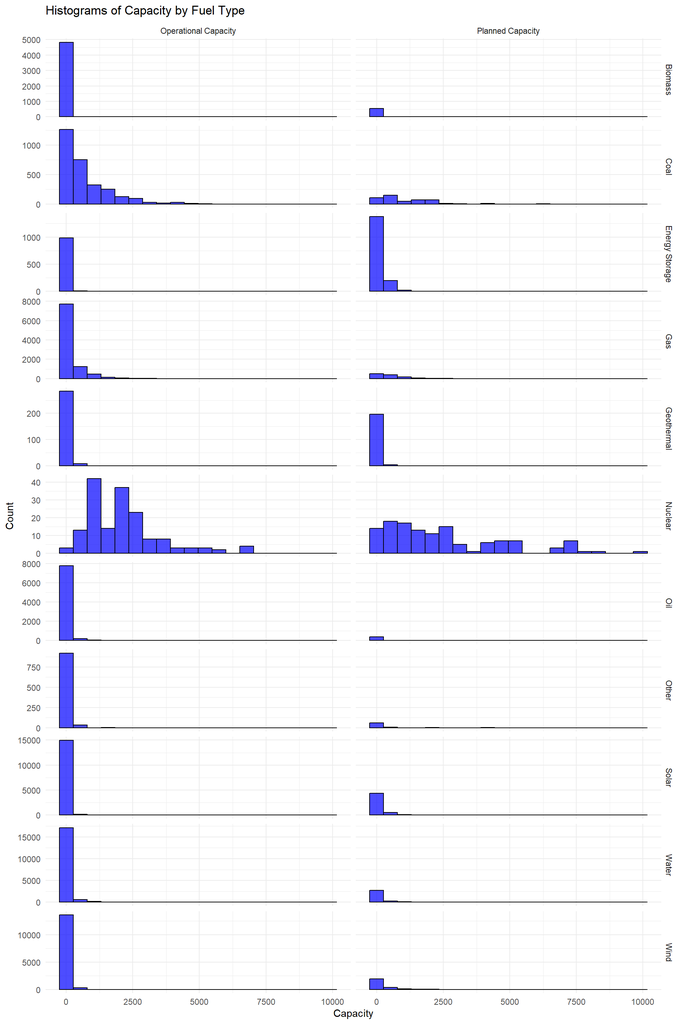